# Ways to find patients with abnormal malignant transcript expression

Claus Scholz

6 November 2018

## Introduction

For the analysis of the malignant/total expression dataset, I present three approaches to identify patients with expression changes between time points. All of them are valid, but if I had to choose one, then I take the last as most appropriate.

## Setup

First, I’ll load some R packages required for the analysis.

```r
library(ggplot2)
library(knitr)
```

## Data Import and Cleaning

To start with the analysis, I’ll load the dataset directly from my forked repository on Github.

```r
input_file_path <- "https://raw.githubusercontent.com/clajusch/exercise/master/raw_data.tsv"
raw_data <- as.matrix(read.table(input_file_path,
                                 header = TRUE,
                                 sep = "\t"))
```

A quick look at the dataset reveals several issues.

```r
dim(raw_data)
```

```
## [1] 22088    16
```

```r
summary(raw_data)
```

```
##    August_1m         August_2m         August_3m         August_4m
##  Min.   :   37.0   Min.   :   36.0   Min.   :   38.0   Min.   :   40.0
##  1st Qu.:   75.0   1st Qu.:   73.0   1st Qu.:   77.0   1st Qu.:  121.0
##  Median :  151.0   Median :  146.0   Median :  155.0   Median :  161.0
##  Mean   :  375.6   Mean   :  354.6   Mean   :  358.8   Mean   :  417.2
##  3rd Qu.:  303.0   3rd Qu.:  293.0   3rd Qu.:  272.0   3rd Qu.:  343.0
##  Max.   :26634.0   Max.   :50147.0   Max.   :33747.0   Max.   :59658.0
##  NA's   :15186     NA's   :14532     NA's   :15136     NA's   :15013
##   December_1m       December_2m       December_3m       December_4m
##  Min.   :   41.0   Min.   :   43.0   Min.   :   34.0   Min.   :   35.0
##  1st Qu.:   83.0   1st Qu.:  130.0   1st Qu.:   68.0   1st Qu.:   70.0
##  Median :  166.0   Median :  173.0   Median :  136.0   Median :  141.0
##  Mean   :  425.4   Mean   :  447.1   Mean   :  384.3   Mean   :  384.9
##  3rd Qu.:  333.0   3rd Qu.:  390.0   3rd Qu.:  307.0   3rd Qu.:  283.0
##  Max.   :80518.0   Max.   :40028.0   Max.   :37610.0   Max.   :49571.0
##  NA's   :14092     NA's   :14266     NA's   :12245     NA's   :12549
##    August_1t            August_2t            August_3t
##  Min.   :-9.223e+18   Min.   :-9.223e+18   Min.   :-9.223e+18
##  1st Qu.: 1.748e+03   1st Qu.: 1.689e+03   1st Qu.: 1.731e+03
##  Median : 3.788e+03   Median : 3.493e+03   Median : 3.620e+03
##  Mean   :       Inf   Mean   :       Inf   Mean   :       Inf
##  3rd Qu.: 8.118e+03   3rd Qu.: 7.336e+03   3rd Qu.: 7.793e+03
##  Max.   :       Inf   Max.   :       Inf   Max.   :       Inf
##  NA's   :15186        NA's   :14532        NA's   :15136
##    August_4t           December_1t          December_2t
##  Min.   :-9.223e+18   Min.   :-9.223e+18   Min.   :-9.223e+18
##  1st Qu.: 1.596e+03   1st Qu.: 1.836e+03   1st Qu.: 1.734e+03
##  Median : 3.415e+03   Median : 4.163e+03   Median : 3.771e+03
##  Mean   :       Inf   Mean   :       Inf   Mean   :       Inf
##  3rd Qu.: 7.132e+03   3rd Qu.: 9.251e+03   3rd Qu.: 7.885e+03
##  Max.   :       Inf   Max.   :       Inf   Max.   :       Inf
##  NA's   :15013        NA's   :14092        NA's   :14266
##   December_3t          December_4t
##  Min.   :-9.223e+18   Min.   :-9.223e+18
##  1st Qu.: 1.706e+03   1st Qu.: 1.609e+03
##  Median : 3.976e+03   Median : 3.712e+03
##  Mean   :       Inf   Mean   :       Inf
##  3rd Qu.: 9.101e+03   3rd Qu.: 7.868e+03
##  Max.   :       Inf   Max.   :       Inf
##  NA's   :12245        NA's   :12549
```

A quite large proportion of the dataset is made up of missing values (`NA`); it furthermore contains negative and infinitive values which don’t make sense in our experimental setting. Thus, negative and infinitive values are set to `NA`.

```r
count_data <- raw_data
count_data[count_data<0 | count_data==Inf] <- NA
```

## The Bioinformatics solution

The Bioinformatics strategy is to first impute missing values with the `imp4p` package and to then perform expression analyses on malignant and normal gene expression using the Bioconductor package `DSS`, which is suited to analyze data that follows a beta binomial distribution. Then, both results will be compared to ensure independence of malignant and normal expression changes.

```r
library(DSS)
library(edgeR)
library(imp4p)
```

### Prediction of Missing Values

Here, I’ll use the `imp4p` package to predict missing values in the dataset.

```r
set.seed(42) # ;-)
experimental_groups <- factor(rep(1:2, each=8))
fake_biol_reps <- factor(rep(1:4, each=4))
count_imp4p <- impute.mi(count_data,
                         conditions = experimental_groups,
                         repbio = fake_biol_reps)
```

[output not shown]

```r
colnames(count_imp4p$tab.imp) <- colnames(count_data)
rownames(count_imp4p$tab.imp) <- paste("patient", 1:nrow(count_imp4p$tab.imp), sep ="_")
```

Let’s have a look at the imputation result:

```r
summary(count_imp4p$tab.imp)
```

```
##    August_1m         August_2m         August_3m         August_4m
##  Min.   :-1053.8   Min.   : -897.4   Min.   : -899.0   Min.   : -881.8
##  1st Qu.:  104.8   1st Qu.:  105.0   1st Qu.:  101.9   1st Qu.:  111.9
##  Median :  139.5   Median :  138.8   Median :  134.1   Median :  149.7
##  Mean   :  334.1   Mean   :  326.4   Mean   :  322.1   Mean   :  361.5
##  3rd Qu.:  303.0   3rd Qu.:  330.0   3rd Qu.:  306.8   3rd Qu.:  352.1
##  Max.   :51460.5   Max.   :51472.1   Max.   :51326.0   Max.   :59658.0
##   December_1m       December_2m       December_3m       December_4m
##  Min.   :-1811.0   Min.   : -874.0   Min.   : -813.7   Min.   : -901.5
##  1st Qu.:  108.9   1st Qu.:  114.7   1st Qu.:  102.0   1st Qu.:  106.0
##  Median :  144.4   Median :  151.3   Median :  136.0   Median :  141.0
##  Mean   :  349.6   Mean   :  352.6   Mean   :  295.2   Mean   :  321.9
##  3rd Qu.:  291.0   3rd Qu.:  287.2   3rd Qu.:  204.0   3rd Qu.:  247.0
##  Max.   :80518.0   Max.   :48487.2   Max.   :53640.7   Max.   :49571.0
##    August_1t          August_2t          August_3t
##  Min.   :   -1329   Min.   :   -1340   Min.   :   -2292
##  1st Qu.:    1359   1st Qu.:    1315   1st Qu.:    1321
##  Median :    3128   Median :    2974   Median :    2998
##  Mean   :    8284   Mean   :    7796   Mean   :    8337
##  3rd Qu.:    6888   3rd Qu.:    6523   3rd Qu.:    6622
##  Max.   :12843476   Max.   :10638382   Max.   :16873860
##    August_4t         December_1t        December_2t
##  Min.   :   -1544   Min.   :   -3207   Min.   :   -1484
##  1st Qu.:    1301   1st Qu.:    1394   1st Qu.:    1344
##  Median :    2900   Median :    3469   Median :    3314
##  Mean   :    7880   Mean   :    9844   Mean   :    8967
##  3rd Qu.:    6230   3rd Qu.:    8326   3rd Qu.:    7653
##  Max.   :12287315   Max.   :13167613   Max.   :13167592
##   December_3t        December_4t
##  Min.   :   -1407   Min.   :   -3575
##  1st Qu.:    1383   1st Qu.:    1314
##  Median :    3412   Median :    3256
##  Mean   :    9716   Mean   :    9464
##  3rd Qu.:    8432   3rd Qu.:    7558
##  Max.   :13167598   Max.   :17031295
```

In the following I do a little data cleaning and calculate normal transcript expression.

```r
malignant_imp4p_counts <- count_imp4p$tab.imp[, 1:8]
malignant_imp4p_counts[malignant_imp4p_counts<0] <- 0
total_imp4p_counts <- count_imp4p$tab.imp[, 9:16]

t_al_m <- total_imp4p_counts>=malignant_imp4p_counts # t at least m
total_imp4p_counts[!t_al_m] <- malignant_imp4p_counts[!t_al_m]

normal_imp4p_counts <- total_imp4p_counts - malignant_imp4p_counts
colnames(normal_imp4p_counts) <- sub("t$", "n", colnames(normal_imp4p_counts))
```

### Exploratory Analysis

I’ll start with a look at the distributions of log10-transformed expression values of total, malignant and normal transcription.

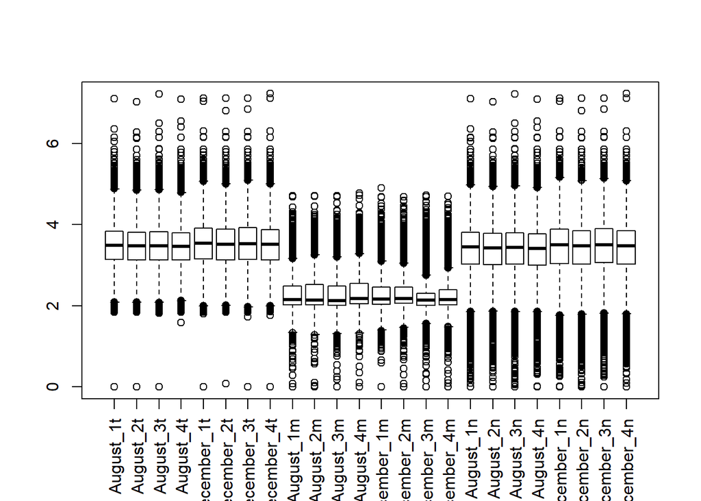

Boxplot

Malignant transcription thus seems to be the minor proportion of total transcription.

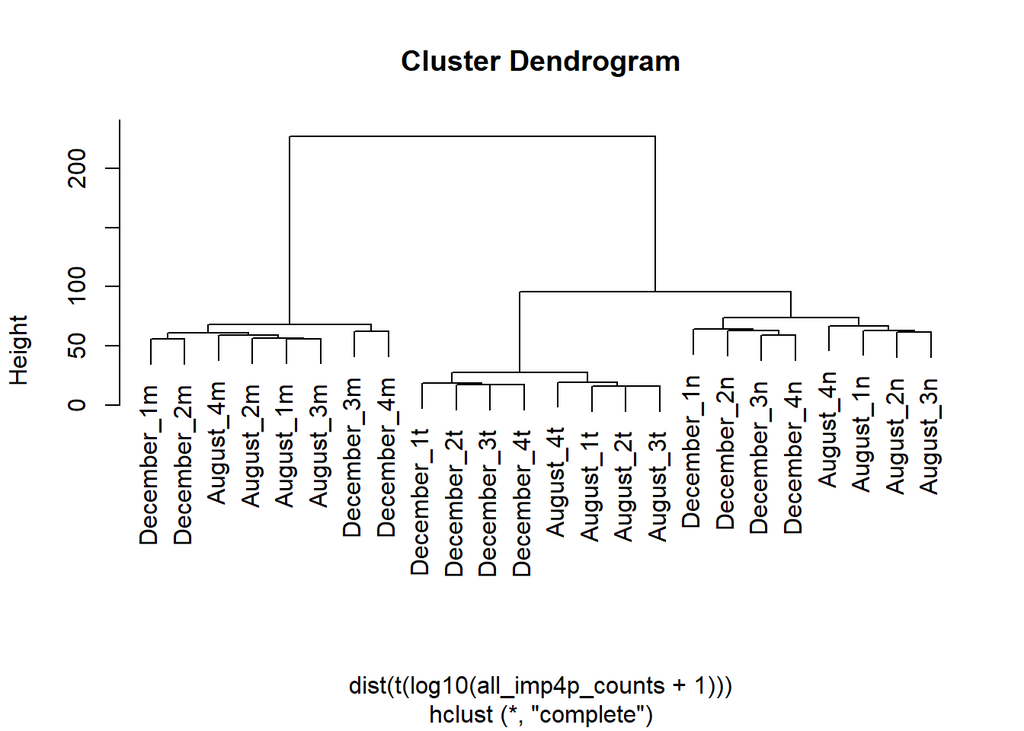

Hierarchical Clustering

#### Malignant Transcription

I’ll start with expression differences between December and August for the malignant isoform alone.

```r
malignant_groups <- rep(c(1, 0), each = 4)
names(malignant_groups) <- colnames(malignant_imp4p_counts)
malignant_changes <- DSS.DE(malignant_imp4p_counts, malignant_groups)
head(malignant_changes)
```

```
##               geneIndex       muA       muB       lfc    difExpr     stats
## patient_16202     16202 116.84543 1724.4416 -2.687826 -1607.5961 -18.00412
## patient_15018     15018  99.59479 1315.7764 -2.576444 -1216.1816 -17.67809
## patient_13605     13605  94.81142  798.9975 -2.126834  -704.1861 -16.36389
## patient_7665       7665  75.49194  680.1521 -2.192424  -604.6602 -16.35413
## patient_13387     13387 101.85132  828.3983 -2.091686  -726.5470 -16.30851
## patient_5850       5850  77.52653  682.6140 -2.169613  -605.0875 -16.30419
##               pval    local.fdr          fdr
## patient_16202    0 4.704065e-29 4.704065e-29
## patient_15018    0 2.982335e-28 0.000000e+00
## patient_13605    0 6.335695e-24 0.000000e+00
## patient_7665     0 6.869284e-24 0.000000e+00
## patient_13387    0 9.364595e-24 0.000000e+00
## patient_5850     0 9.601214e-24 0.000000e+00
```

#### Normal Transcription

Now let’s do the same for normal transcription.

```r
normal_groups <- rep(c(1, 0), each = 4)
names(normal_groups) <- colnames(normal_imp4p_counts)
normal_changes <- DSS.DE(normal_imp4p_counts, normal_groups)
head(normal_changes)
```

```
##               geneIndex       muA      muB       lfc     difExpr     stats
## patient_15764     15764  355.3367     0.00  6.567619    355.3367  17.86991
## patient_16949     16949  346.1121     0.00  6.541354    346.1121  17.82313
## patient_13172     13172  262.8108     0.00  6.266482    262.8108  17.28006
## patient_11983     11983  475.3800     0.00  6.858313    475.3800  17.13329
## patient_18           18 4233.5394 29876.21 -1.953923 -25642.6754 -16.91832
## patient_9296       9296  304.7392  2405.86 -2.064775  -2101.1212 -16.90574
##               pval    local.fdr          fdr
## patient_15764    0 1.568628e-11 1.568628e-11
## patient_16949    0 1.568628e-11 1.568612e-11
## patient_13172    0 6.526764e-11 5.411538e-11
## patient_11983    0 9.302398e-11 5.411538e-11
## patient_18       0 9.643395e-11 7.173417e-11
## patient_9296     0 9.643395e-11 7.173417e-11
```

#### Malignant vs Normal Changes

I’ll first visually inspect how normal transcript chances relate to those of the malignant transcript. For this, the result tables need to be resorted.

```r
malignant_changes <- malignant_changes[order(malignant_changes$geneIndex),]
normal_changes <- normal_changes[order(normal_changes$geneIndex),]
```

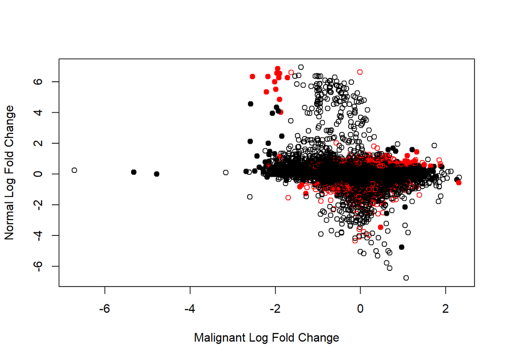

Log Fold Change Scatterplot

Filled circles indicate significant changes in malignant transcription (open circles are non-significant), red color highlights significant changes in normal transcription (black is non-significant). Results depend on the imputation, bur for simplicity let’s assume all malignant changes are independent of normal changes. The number of patients with changed malignant transcription is the following:

```r
table(malignant_changes$fdr<0.05)
```

```
##
## FALSE  TRUE
## 21311   777
```

## The Simple Statistics Solution

Our dataset is made up of two groups (August and December) with malignant and a complementary gene expression measure provided as read counts. I’ll therefore compare counts for each patient between time points with 2x2 contingency tables.

### Summary of Technical Replicates

RNA-seq library preparation involves the exponential amplification of cDNA using PCR. Thus, I’ll use the geometric mean to summarize technical replicates.

```r
geometric_mean = function(x) {
  non_missing <- na.omit(x)
  gm <- if (length(non_missing)>0) {
    if (any(non_missing!=0)) {
      exp(mean(log(non_missing[non_missing>0])))
    } else 0
  } else NA
  return(gm)
}
```

The function explicitly ignores missing values and should therefore make more samples available for analysis. To illustrate this, let’s first check the number of samples containing missing values.

```r
table(apply(count_data, 1, function(x) any(is.na(x))))
```

```
##
## FALSE  TRUE
##  2158 19930
```

This is quite a lot! Here I’ll summarize technical replicates.

```r
columns <- list(August_m=1:4, December_m=5:8, August_t=9:12, December_t=13:16)
count_gm <- sapply(columns, function(x) apply(count_data[, x], 1, geometric_mean))
rownames(count_gm) <- paste("patient", 1:nrow(count_gm), sep = "_")
```

Now let’s check if the summary statistics make sense, i.e. that the total gene expression is at least as high as the expression of the malignant isoform.

```r
all(count_gm[, "August_t"]>=count_gm[, "August_m"], na.rm = TRUE) &
  all(count_gm[, "December_t"]>=count_gm[, "December_m"], na.rm = TRUE)
```

```
## [1] TRUE
```

That looks fine, so let’s check how many of the summarized samples contain missing values.

```r
table(apply(count_gm, 1, function(x) any(is.na(x))))
```

```
##
## FALSE  TRUE
##  9233 12855
```

The summary procedure rescued roughly 7,000 samples, but still the majority contains missing values.

### Prediction of Missing Values

Before missing value imputation, I’ll have a closer look at the data to choose an appropriate prediction strategy.

```r
cor(na.omit(count_gm))
```

```
##             August_m December_m  August_t December_t
## August_m   1.0000000  0.9097167 0.2313012  0.2042762
## December_m 0.9097167  1.0000000 0.1292270  0.1076042
## August_t   0.2313012  0.1292270 1.0000000  0.9487677
## December_t 0.2042762  0.1076042 0.9487677  1.0000000
```

This reaveals a strong correlation of malignant expression between timepoints and total expression between time points. Since Pearson correaltion was used on untransformed counts there is a linear relationship. For the two expression types, I’ll calculate the late vs early ratio.

```r
malignant_ratio <- mean(count_gm[, 2] / count_gm[, 1], na.rm = TRUE)
total_ratio <- mean(count_gm[, 4] / count_gm[, 3], na.rm = TRUE)
```

Let’s see how many missing values I can predict with these ratios.

```r
missing_values <- data.frame(is.na(count_gm))
```

These are the missing value combinations in the malignant expression values…

```r
ftable(August_m~December_m, data = missing_values)
```

```
##            August_m FALSE TRUE
## December_m
## FALSE                9270 7657
## TRUE                 5161    0
```

… and the total expression.

```r
ftable(August_t~December_t, data = missing_values)
```

```
##            August_t FALSE TRUE
## December_t
## FALSE                9233 7613
## TRUE                 5105  137
```

With the ratio approach, I will rescue almost all missing data and only a small proportion cannot be predicted. So let’s go ahead:

```r
count_imp <- count_gm

count_imp[missing_values$August_m, "August_m"] <-
  count_gm[missing_values$August_m, "December_m"] / malignant_ratio

count_imp[missing_values$December_m, "December_m"] <-
  count_gm[missing_values$December_m, "August_m"] * malignant_ratio

count_imp[missing_values$August_t, "August_t"] <-
  count_gm[missing_values$August_t, "December_t"] / total_ratio

count_imp[missing_values$December_t, "December_t"] <-
  count_gm[missing_values$December_t, "August_t"] * total_ratio
```

The sanity check of the resulting values however points to a problem…

```r
all(count_imp[, "August_t"]>=count_imp[, "August_m"], na.rm = TRUE) &
  all(count_imp[, "December_t"]>=count_imp[, "December_m"], na.rm = TRUE)
```

```
## [1] FALSE
```

… which I quickly fix.

```r
index <- which(count_imp[, "December_t"]<count_imp[, "December_m"])
count_imp[index, "December_t"] <- count_imp[index, "December_m"]
```

### Expression Analysis

We aim at finding patients with expression changes in the malignant isoform that are independent of the expression of other isoforms. For the analysis I therefore calculate the normal (`n`) gene expression.

```r
simple_analysis <- data.frame(August_m = count_imp[, "August_m"],
                              August_n = count_imp[, "August_t"] - count_imp[, "August_m"],
                              December_m = count_imp[, "December_m"],
                              December_n = count_imp[, "December_t"] - count_imp[, "December_m"],
                              imputed = apply(missing_values, 1, any),
                              row.names = rownames(count_imp))
```

With this I’ll calculate the log2(odds ratio) between August and December as effect size.

```r
log_odds_ratio <- function(x) {
  odds_ratio <- (x[1]*x[4]) / (x[2]*x[3])
  return(log2(odds_ratio))
}

simple_analysis$log2_OR <- apply(simple_analysis[, 1:4], 1, log_odds_ratio)
```

Then I’ll calculate p-values using chi-squared tests and estimate the false discovery rate twice, once for p-values including and once for those excluding the imputed samples.

```r
simple_analysis$p.value <- apply(simple_analysis[, 1:4], 1,
                                 function(x) ifelse(any(is.na(x)), NA,
                                                    chisq.test(matrix(x, ncol=2))$p.value))
simple_analysis$fdr_w_imp <- p.adjust(simple_analysis$p.value)
simple_analysis$fdr_wo_imp <- NA
simple_analysis$fdr_wo_imp[!simple_analysis$imputed] <- p.adjust(simple_analysis$p.value[!simple_analysis$imputed])
```

The distribution of nominal p-values…

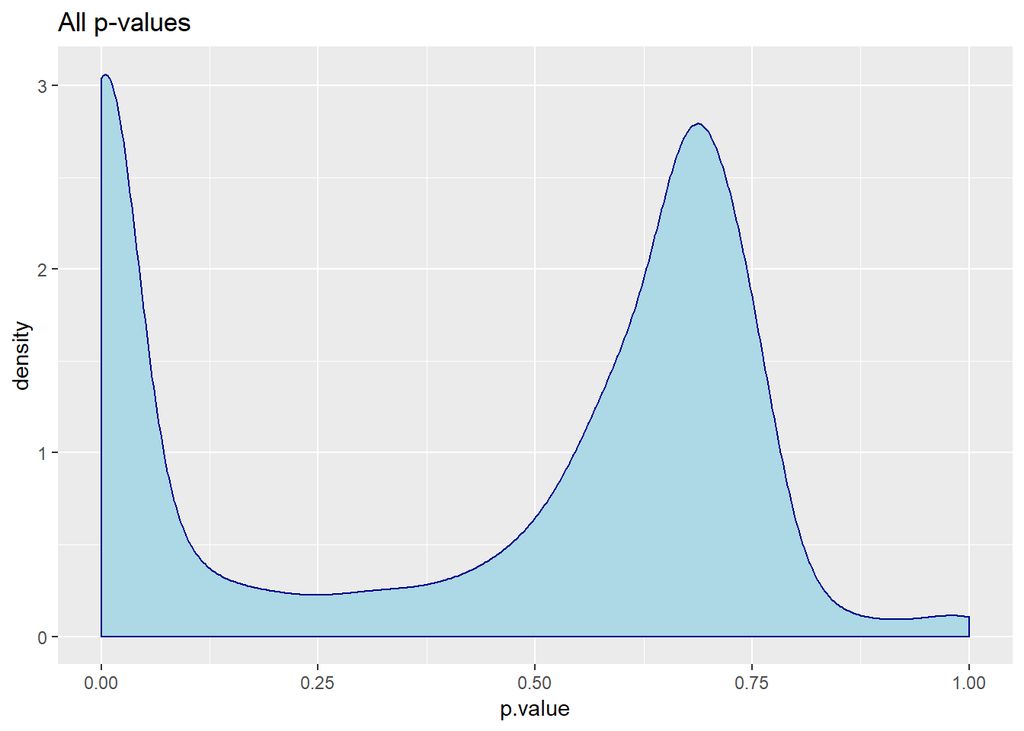

… is bimodal with an inflation of small p-values and a high proportion of p-values in the 0.5-0.8 range, which is probably an artifact from data imputation. Therefore let’s have a look at the distribution of p-values from non-imputed samples:

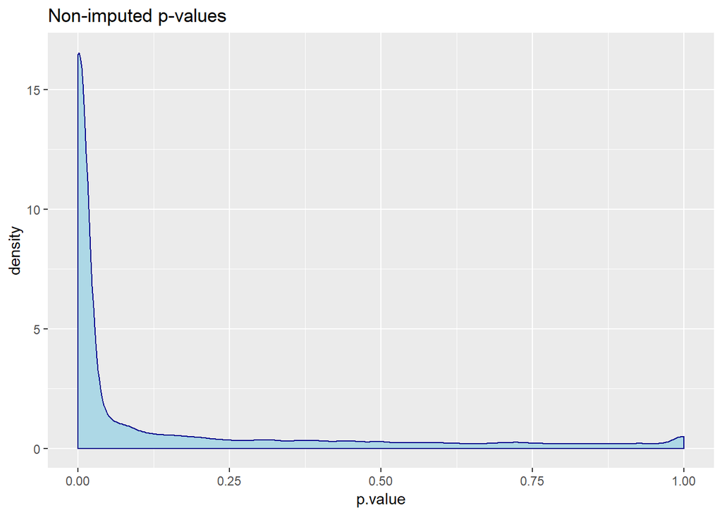

This confirms that the imputed samples cause the peak of p-values in the 0.5-0.8 range. Other imputation strategies might give better results.

Now let’s see how many tests resist the correction for multiple testing, firstly considering all examined samples…

```r
sig_w_imp <- simple_analysis$fdr_w_imp<0.05
table(sig_w_imp)
```

```
## sig_w_imp
## FALSE  TRUE
## 18540  3331
```

… secondly only the non-imputed samples…

```r
sig_wo_imp <- simple_analysis$fdr_wo_imp<0.05
table(sig_wo_imp)
```

```
## sig_wo_imp
## FALSE  TRUE
##  5737  3485
```

… and the concordance of results:

```r
ftable(sig_w_imp~sig_wo_imp)
```

```
##            sig_w_imp FALSE TRUE
## sig_wo_imp
## FALSE                 5737    0
## TRUE                   197 3288
```

I.e. due to the increased multiple testing problem in the imputed analysis setting, no expression differences are detectable between time points in some borderline samples. But are there some among the imputed samples?

```r
table(subset(simple_analysis, imputed)$fdr_w_imp<0.05)
```

```
##
## FALSE  TRUE
## 12606    43
```

Yes indeed there are some!

Now let’s proceed with the…

## The Sophisticated Statistics Solution

With this approach, I’ll examine the proportions of maligant to total gene expression.

```r
library(stats4)
library(MASS)
```

### Aggregation of Technical Replicates

Technically replicated read counts per gene origin from the same sample and may - ignoring e.g. sequencing batch effects - be cumulated to result in higher information content.

```r
count_cumulated <- data.frame(August_m = apply(count_data[, 1:4], 1, sum, na.rm = TRUE),
                              December_m = apply(count_data[, 5:8], 1, sum, na.rm = TRUE),
                              August_t = apply(count_data[, 9:12], 1, sum, na.rm = TRUE),
                              December_t = apply(count_data[, 13:16], 1, sum, na.rm = TRUE),
                              row.names = paste("patient", 1:nrow(count_data), sep = "_"))
```

Later I might need the normal expression values, so I’ll add these here.

```r
count_cumulated$August_n <- with(count_cumulated, August_t-August_m)
count_cumulated$December_n <- with(count_cumulated, December_t-December_m)
```

For correct estimation of malignant proportions, it’s important to have the same number of missing values in malignant and total read-out, therefore I’ll check the balanced occurrence of missing values.

```r
na_balanced <- function(x) sum(is.na(x[1:4]))==sum(is.na(x[5:8]))
count_cumulated$August_balanced <- apply(count_data[, c(1:4, 9:12)], 1, na_balanced)
count_cumulated$December_balanced = apply(count_data[, c(5:8, 13:16)], 1, na_balanced)
```

Balanced missing values in technical replicates and non-missing cumulated expression values make samples accessible for analysis. Let’s check malignant expression in August…

```r
ftable(is.na(August_m)~August_balanced, data=count_cumulated)
```

```
##                 is.na(August_m) FALSE
## August_balanced
## FALSE                             103
## TRUE                            21985
```

… total expression in August…

```r
ftable(is.na(August_t)~August_balanced, data=count_cumulated)
```

```
##                 is.na(August_t) FALSE
## August_balanced
## FALSE                             103
## TRUE                            21985
```

… malignant expression in December …

```r
ftable(is.na(December_m)~December_balanced, data=count_cumulated)
```

```
##                   is.na(December_m) FALSE
## December_balanced
## FALSE                                  91
## TRUE                                21997
```

… and total expression in December:

```r
ftable(is.na(December_t)~December_balanced, data=count_cumulated)
```

```
##                   is.na(December_t) FALSE
## December_balanced
## FALSE                                  91
## TRUE                                21997
```

With this approach, I can analyze almost the entire dataset without imputation of missing values! In the following sections, I’ll therefore only concentrate on the balanced samples.

```r
count_cumulated$analyze <- count_cumulated$August_balanced & count_cumulated$December_balanced
table(count_cumulated$analyze)
```

```
##
## FALSE  TRUE
##   164 21924
```

### Estimation of Beta Distribution

Proportions of malignant to total transcript expressions follow a beta distribution. To account for varying information content, I’ll estimate the prior beta distributions for both time points and shrink proportions towards the prior based on information content.

```r
count_cumulated$August_prior <- NA
tmp_m <- count_cumulated$August_m[count_cumulated$analyze]
tmp_t <- count_cumulated$August_t[count_cumulated$analyze]
count_cumulated$August_prior[count_cumulated$analyze] <- tmp_m/tmp_t
count_cumulated$December_prior <- NA
tmp_m <- count_cumulated$December_m[count_cumulated$analyze]
tmp_t <- count_cumulated$December_t[count_cumulated$analyze]
count_cumulated$December_prior[count_cumulated$analyze] <- tmp_m/tmp_t
```

I’ll introduce a convenience function:

```r
find_beta_shape <- function(x, start = list(shape1=1, shape2=10)) {
  x <- na.omit(x)
  x <- x[x!=0 & x!=1]
  fit <- MASS::fitdistr(x = x, densfun = dbeta, start = start)
  return(fit$estimate)
}
```

And with this, I find shape parameters for the priors for August…

```r
August_shape <- find_beta_shape(count_cumulated$August_prior)
August_shape
```

```
##    shape1    shape2
## 0.6020627 4.5859808
```

… and December:

```r
December_shape <- find_beta_shape(count_cumulated$December_prior)
December_shape
```

```
##    shape1    shape2
## 0.5261792 3.5725604
```

Given these shape parameters, I’ll update prior malignant transcript proportions to obtain posterior means shrunken towards the overall mean depending on information content. Since shape parameters are small compared to the read counts, the empirical Bayesian shrinkage will have only a minor effect.

```r
count_cumulated$August_shape1 <- count_cumulated$August_m+August_shape[1]
count_cumulated$August_shape2 <- count_cumulated$August_n+August_shape[2]
count_cumulated$August_posterior <- with(count_cumulated,
                                         August_shape1/(August_shape1+August_shape2))
count_cumulated$August_posterior[!count_cumulated$analyze] <- NA

count_cumulated$December_shape1 <- count_cumulated$December_m+December_shape[1]
count_cumulated$December_shape2 <- count_cumulated$December_n+December_shape[2]
count_cumulated$December_posterior <- with(count_cumulated,
                                         December_shape1/(December_shape1+December_shape2))
count_cumulated$December_posterior[!count_cumulated$analyze] <- NA
```

### Hypothesis Testing

For both time points, I have now posterior malignant transcript proportions and shape parameters for beta distributions. With these I can compare gene expression between time points.

#### Effect Size

Expression analysis is performed on proportions; thus, the appropriate effect size is the relative risk, which I subject to log2 transformation for symmetry reasons.

```r
count_cumulated$log2RR <- with(count_cumulated, log2(December_posterior/August_posterior))
count_cumulated$log2RR[!count_cumulated$analyze] <- NA
```

#### Statistical Significance

To assess statistical significance, I calculate empirical p-values by comparing randomly generated data using the distribution parameters from the two time points. First, I implement a helper function for more convenient calculations.

```r
empirical_pvalue <- function(v, size = 1e4) {
  es <- v[1]
  early_sim <- rbeta(size, v[2], v[3])
  late_sim <- rbeta(size, v[4], v[5])
  emp_p <- if (es>0) {
    1-mean(late_sim>early_sim)
  } else {
    1-mean(early_sim>late_sim)
  }
  return(emp_p)
}
```

Then I use this for calculation of empirical p-values. To keep this approach reproducible, I fix the random seed.

```r
rel_clms <- c("log2RR", "August_shape1", "August_shape2", "December_shape1", "December_shape2")
count_cumulated$emp_pval <- NA
set.seed(42) # ;-)
count_cumulated$emp_pval[count_cumulated$analyze] <- apply(subset(count_cumulated, analyze)[, rel_clms], 1,
                                                           empirical_pvalue)
```

Let’s first have a look at the distribution of empirical p-values:

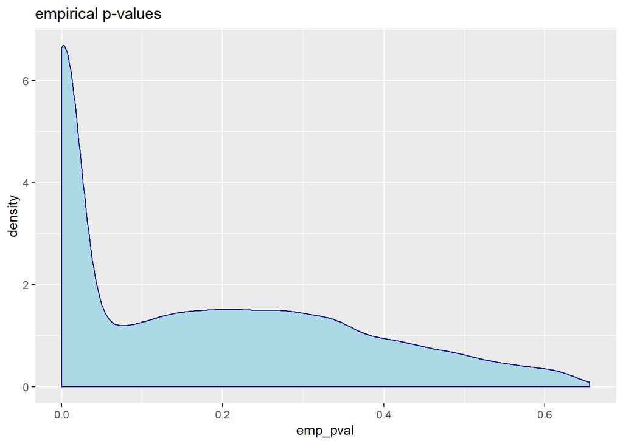

Empirical P-Value Distribution

Then the obtained empirical p-values are adjusted for multiple testing.

```r
count_cumulated$fdr <- NA
count_cumulated$fdr[count_cumulated$analyze] <- p.adjust(count_cumulated$emp_pval[count_cumulated$analyze])
```

How many FDRs are below 5% (which I define as my significance threshold)?

```r
table(count_cumulated$fdr<0.05)
```

```
##
## FALSE  TRUE
## 16258  5666
```

## Result Comparison

The three approaches yielded different numbers of patients with significant expression changes of the malignant transcript between August and December. I’m now interested in the concodance of results. For this is build a table indicating which approach detected a significant change in which patient.

```r
result_table <- data.frame(bioinformatics = malignant_changes$fdr<0.05,
                           simple_stats = simple_analysis$fdr_wo_imp<0.05,
                           sophisticated_stats = count_cumulated$fdr<0.05,
                           row.names = rownames(count_cumulated))
result_table$bioinformatics[is.na(result_table$bioinformatics)] <- FALSE
result_table$simple_stats[is.na(result_table$simple_stats)] <- FALSE
result_table$sophisticated_stats[is.na(result_table$sophisticated_stats)] <- FALSE
```

The overlap between approaches is shown in a Venn Diagram.

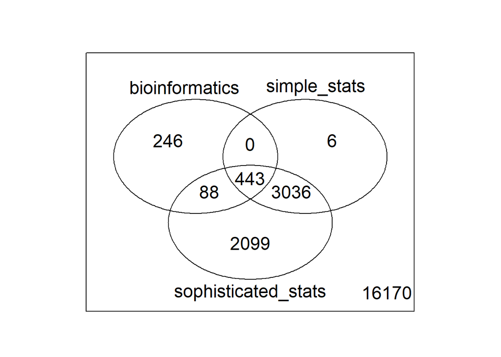

Venn Diagram

## Conclusion

There is a set of patients that are concordantly diagnosed with malignant expression changes by all three approaches. The bioinformatics approach, which detected the least changes, has also the lowest overlap with the other detection strategies in terms of absolute counts. Both statistics approaches show, despite different handling of missing values, a very high degree of overlap. The sophisticated statistics approach is by far the most powerful one and is thus the method of choice for this analysis setting.